# step 5 meta-regression and visualization

Zachary Amir

2025-03-01 14:56:42

## Introduction

This RMarkdown file will be used to implement a meta-regression on the coefficients of preferred predator-prey co-abundance models. The goal of this exercise is to examine the effect of observed variables mediating predator-prey relationships and deepen our understanding of possible unmeasured variables mediating observed relationships.

Before we begin the meta-regressions, it will be important to examine the summary statistics of the posterior effect sizes from our key variables: HFP & FLII & Elevation & Community_detections & Species_Interaction & Active_cams from all 64 preferred predator-prey co-abundance models.

- For HFP, the mean effect size is -0.27 with a standard deviation of 0.67, and the values range from -3.45 to 1.79 with a variance of 0.45.
  - For supported top-down models, the mean effect size is 0.08 with a standard deviation of 0.32
  - For supported bottom-up models, the mean effect size is -0.44 with a standard deviation of 0.77
  - For unsupported models, the mean effect size is -0.24 with a standard deviation of 0.65
- For FLII, the mean effect size is 0.23 with a standard deviation of 0.46, and the values range from -0.79 to 1.34 with a variance of 0.21.
  - For supported top-down models, the mean effect size is -0.18 with a standard deviation of 0.31
  - For supported bottom-up models, the mean effect size is 0.34 with a standard deviation of 0.39
  - For unsupported models, the mean effect size is 0.22 with a standard deviation of 0.47
- For Elevation, the mean effect size is 0.48 with a standard deviation of 0.68, and the values range from -0.58 to 2.64 with a variance of 0.46.
  - For supported top-down models, the mean effect size is 0.93 with a standard deviation of 1
  - For supported bottom-up models, the mean effect size is 0.39 with a standard deviation of 0.6
  - For unsupported models, the mean effect size is 0.49 with a standard deviation of 0.68
- For Community_detections, the mean effect size is 0.26 with a standard deviation of 0.22, and the values range from -0.48 to 1.13 with a variance of 0.05.
  - For supported top-down models, the mean effect size is 0.27 with a standard deviation of 0.14
  - For supported bottom-up models, the mean effect size is 0.27 with a standard deviation of 0.14
  - For unsupported models, the mean effect size is 0.25 with a standard deviation of 0.24
- For Species_Interaction, the mean effect size is 0.16 with a standard deviation of 0.41, and the values range from -1.35 to 1.15 with a variance of 0.17.
  - For supported top-down models, the mean effect size is -0.34 with a standard deviation of 0.24
  - For supported bottom-up models, the mean effect size is 0.2 with a standard deviation of 0.16
  - For unsupported models, the mean effect size is 0.17 with a standard deviation of 0.45
- For Active_cams, the mean effect size is 0.36 with a standard deviation of 0.13, and the values range from 0.15 to 0.8 with a variance of 0.02.
  - For supported top-down models, the mean effect size is 0.39 with a standard deviation of 0.1
  - For supported bottom-up models, the mean effect size is 0.33 with a standard deviation of 0.12
  - For unsupported models, the mean effect size is 0.36 with a standard deviation of 0.14

## Regressions

These regressions are using all posterior effect sizes from the 64 for the key covariates described above. Only the results from the subordinate species are included in these regressions to ensure a fair comparison with SIV because it is only present in the subordinate species’ co-abundance model. The co-abundance model results have been split into four groupings: supported_bottom-up, supported_top-down, unsupported_bottom-up, unsupported_top-down for a total of four linear (i.e. Gaussian distribution) mixed effect models with a random effect per subordinate species. Each regression’s response variable is the posterior effect size, and each effect size is weighted by 1/standard deviation of the posterior effect size. The predictor variable is a categorical variable denoting the variable of interest: Community_detections, Elevation, FLII, HFP, SIV.

Before we create the graph, we can display the values produced in the regression for each of the variables.

- For HFP, the average effect size across the four groupings used in the meta-regression is -0.14 with a standard deviation of 0.23.
  - For supported top-down models, the overall effect size is 0.14 with a standard error of 0.15 and a p-value of 0.384.
  - For unsupported top-down models, the overall effect size is -0.09 with a standard error of 0.07 and a p-value of 0.236.
  - For supported bottom-up models, the overall effect size is -0.23 with a standard error of 0.18 and a p-value of 0.207.
  - For unsupported bottom-up models, the overall effect size is -0.39 with a standard error of 0.16 and a p-value of 0.019.
- For FLII, the average effect size from the meta-regression is 0.19 with a standard deviation of 0.2.
  - For supported top-down models, the overall effect size is -0.02 with a standard error of 0.13 and a p-value of 0.874.
  - For unsupported top-down models, the overall effect size is 0.15 with a standard error of 0.07 and a p-value of 0.04.
  - For supported bottom-up models, the overall effect size is 0.46 with a standard error of 0.14 and a p-value of 0.006.
  - For unsupported bottom-up models, the overall effect size is 0.18 with a standard error of 0.13 and a p-value of 0.179.
- For Elevation, the average effect size from the meta-regression is 0.37 with a standard deviation of 0.39.
  - For supported top-down models, the overall effect size is 0.12 with a standard error of 0.12 and a p-value of 0.37.
  - For unsupported top-down models, the overall effect size is -0.03 with a standard error of 0.06 and a p-value of 0.606.
  - For supported bottom-up models, the overall effect size is 0.58 with a standard error of 0.12 and a p-value of 0.002.
  - For unsupported bottom-up models, the overall effect size is 0.81 with a standard error of 0.11 and a p-value of 0.
- For Community_detections, the average effect size from the meta-regression is 0.33 with a standard deviation of 0.07.
  - For supported top-down models, the overall effect size is 0.32 with a standard error of 0.09 and a p-value of 0.057.
  - For unsupported top-down models, the overall effect size is 0.24 with a standard error of 0.05 and a p-value of 0.
  - For supported bottom-up models, the overall effect size is 0.34 with a standard error of 0.1 and a p-value of 0.026.
  - For unsupported bottom-up models, the overall effect size is 0.41 with a standard error of 0.09 and a p-value of 0.017.
- For SIV, the average effect size across the four groupings used in the meta-regression is 0.09 with a standard deviation of 0.29.
  - For supported top-down models, the overall effect size is -0.29 with a standard error of 0.13 and a p-value of 0.083.
  - For unsupported top-down models, the overall effect size is 0.41 with a standard error of 0.05 and a p-value of 0.
  - For supported bottom-up models, the overall effect size is 0.19 with a standard error of 0.09 and a p-value of 0.134.
  - For unsupported bottom-up models, the overall effect size is 0.06 with a standard error of 0.09 and a p-value of 0.574.

For each level of support (i.e. unsupported, bottom-up, top-down), documenting sample sizes is important!

- For supported top-down models, there are 2 results.
- For unsupported top-down models, there are 30 results.
- For supported bottom-up models, there are 12 results.
- For unsupported bottom-up models, there are 20 results.

For reference, this is what variable each letter represents on the plot:

- The letter D) corresponds to the variable **Community_detections**
- The letter C) corresponds to the variable **Elevation**
- The letter B) corresponds to the variable **FLII**
- The letter A) corresponds to the variable **HFP**
- The letter E) corresponds to the variable **SIV**

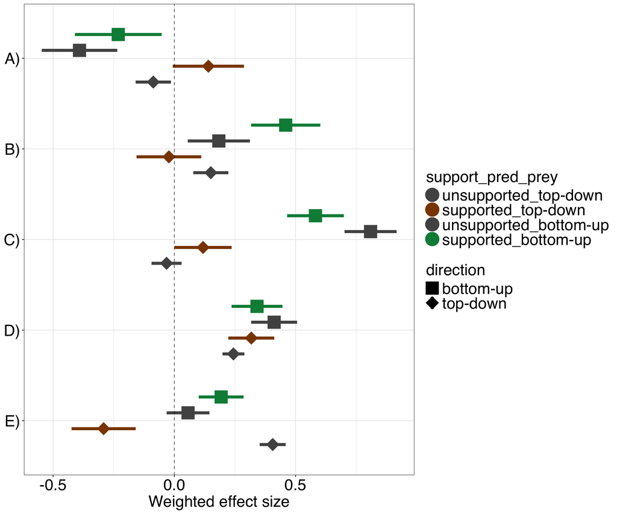

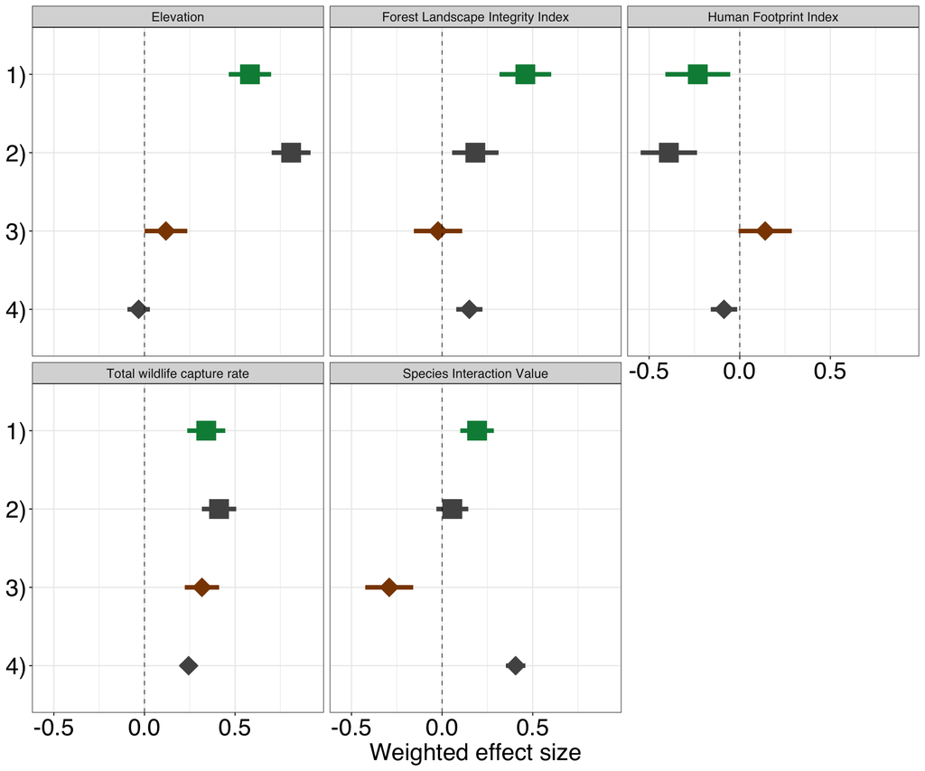

Below is a simplified version of the forest plot, where supported and unsupported models have been combined to examine predator and prey groupings independently. To ensure the results are not skewed by poor models, **18 models with a poor goodness of fit or SIV parameters that did not converge (i.e., unsupported_3) have been removed** from this analysis.

Here are the numerical **results for predators**:

- The variable **Community_detections** had an effect size of 0.402 and a standard error of 0.093 and a p-value of 0.016
- The variable **Elevation** had an effect size of 0.681 and a standard error of 0.101 and a p-value of 0.001
- The variable **FLII** had an effect size of 0.32 and a standard error of 0.118 and a p-value of 0.024
- The variable **HFP** had an effect size of -0.322 and a standard error of 0.141 and a p-value of 0.035
- The variable **SIV** had an effect size of 0.118 and a standard error of 0.088 and a p-value of 0.276

Here are the numerical **results for prey**:

- The variable **Community_detections** had an effect size of 0.245 and a standard error of 0.052 and a p-value of 0
- The variable **Elevation** had an effect size of 0.027 and a standard error of 0.073 and a p-value of 0.715
- The variable **FLII** had an effect size of 0.136 and a standard error of 0.087 and a p-value of 0.124
- The variable **HFP** had an effect size of -0.048 and a standard error of 0.087 and a p-value of 0.577
- The variable **SIV** had an effect size of 0.227 and a standard error of 0.066 and a p-value of 0.001

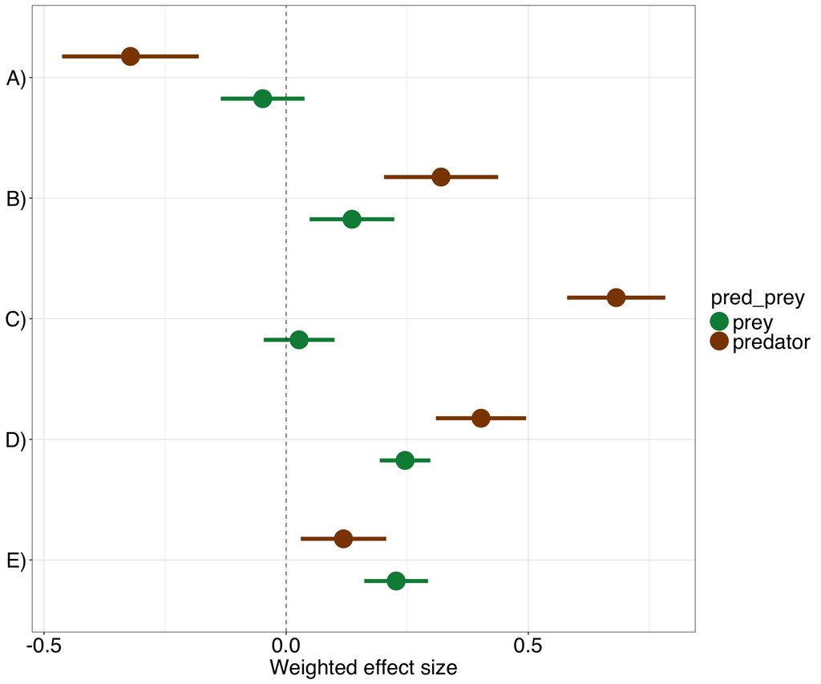

## Save everything!

Its going here in dropbox: Dropbox/Zach PhD/Ch3 Trophic release project/SEA_TC_GitHub_data_storage/figures/step5_output_forest_plot/